```r
library(tsDyn)
summary(VECM(r, 2, estim="ML"))
```

```
## #############
## ###Model VECM
## #############
## Full sample size: 2383   End sample size: 2380
## Number of variables: 2   Number of estimated slope parameters 12
## AIC -19907.66    BIC -19832.58   SSR 173.3685
## Cointegrating vector (estimated by ML):
##    X3m       X6m
## r1   1 -1.012439
##
##
##              ECT                 Intercept           X3m -1
## Equation X3m -0.0949(0.0199)***  -0.0217(0.0061)***  0.0466(0.0480)
## Equation X6m -0.0211(0.0179)     -0.0051(0.0055)     -0.0419(0.0432)
##              X6m -1            X3m -2              X6m -2
## Equation X3m 0.2650(0.0538)*** -0.2067(0.0481)***  0.2547(0.0543)***
## Equation X6m 0.3164(0.0484)*** -0.0346(0.0433)     0.0994(0.0488)*
```

The results are very similar. We can further observe and check the residuals:

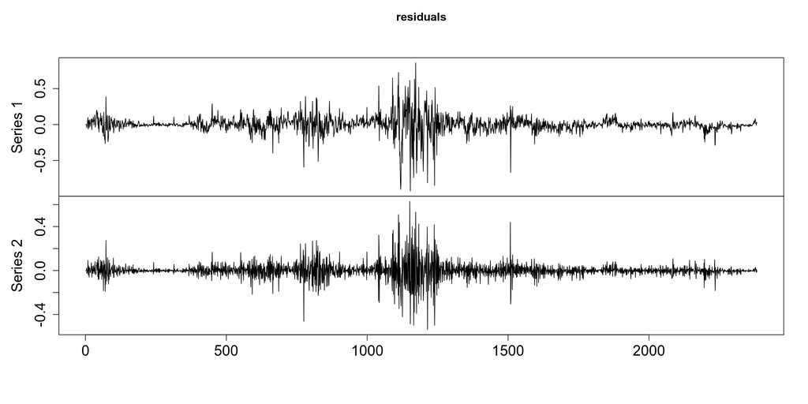

```r
N <- nrow(r)
r <- as.matrix(r)
pars <- extract(fit_ECM_treasury)
c0 <- colMeans(pars$c0)
alpha <- colMeans(pars$alpha)
beta <- mean(pars$beta)
phi <- apply(pars$phi, c(2,3,4), mean)
residuals <- matrix(nrow = N, ncol = 2)
residuals[1:3,] <- 0
for(t in 4:N)
  residuals[t,] <-  c0 + (alpha %*% (c(1,-beta) %*% r[t-1,])) + phi[,,1] %*% (r[t-1,] - r[t-2,]) + phi[,,2] %*% (r[t-2,] - r[t-3,])
plot.ts(residuals, cex.axis=1.5, cex.lab=1.5, xlab="")
```

A further analysis of the cointegrating residuals reveals the time series distance between the two assets:

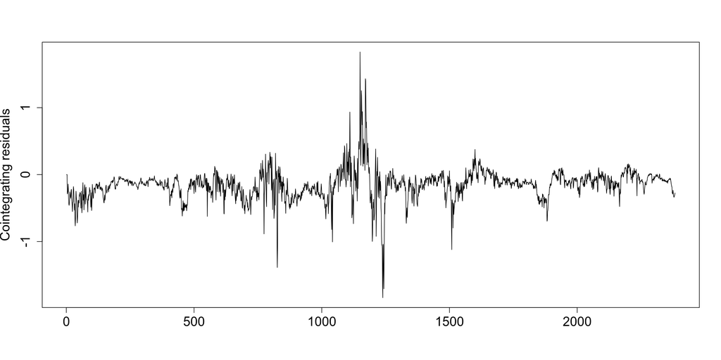

```r
r_hat <- matrix(nrow = N, ncol = 2)
r_hat[1:3,] <- 0
for(t in 4:N)
  r_hat[t,] <- r[t-1,] + c0 + (alpha %*% (c(1,-beta) %*% r[t-1,])) + phi[,,1] %*% (r[t-1,] - r[t-2,]) + phi[,,2] %*% (r[t-2,] - r[t-3,])
plot(r_hat[,1] - r_hat[,2] , type="l", cex.axis=1.5, cex.lab=1.5, xlab="", ylab="Cointegrating residuals")
```

## 8.8 PAIRS TRADING

We are going to use cointegration to show a simple example of pairs trading. This kind of strategy involves asset that tend to move along a common trend and exploits divergences along the path to sell the overpriced asset and to buy the underpriced. one. The difference between the two observed prices is called the spread. For pairs trading, the greater the spread, the larger the magnitude of mispricing and the greater the profit potential. See Vidyamurthy (2004), Pole (2007), Chan (2013) and https://hudsonthames.org/arbitragelab/ for more info.  
To demonstrate pairs trading, Tsay considers two stocks traded on the New York Stock Exchange. The two companies are the Billiton Ltd. of Australia and the Vale S.A. of Brazil with stock symbols BHP and VALE, respectively:

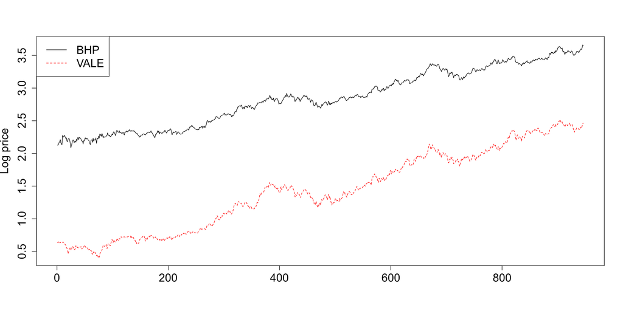

```r
BHP <- read.table("data/d-bhp0206.txt", header=T)
VALE <- read.table("data/d-vale0206.txt", header=T)
Stocks <- data.frame(BHP=BHP$adjclose %>% log, VALE=VALE$adjclose %>% log)
matplot(Stocks, ylab="Log price", type="l", col=c("black", "red"), cex.axis=1.5, cex.lab=1.5, xlab="");
legend('topleft',legend = colnames(Stocks), col = c('black','red'), lty=1:2, cex=1.5)
```

A simple linear regression already confirms that there is some sort of relationship between the two stocks:

```r
library(tseries)
fit <- lm(BHP ~ VALE, Stocks)
summary(fit)
```

```
##
## Call:
## lm(formula = BHP ~ VALE, data = Stocks)
##
## Residuals:
##       Min        1Q    Median        3Q       Max
## -0.151818 -0.028265  0.003121  0.029803  0.147105
##
## Coefficients:
##             Estimate Std. Error t value Pr(>|t|)
## (Intercept) 1.822648   0.003662   497.7   <2e-16 ***
## VALE        0.716664   0.002354   304.4   <2e-16 ***
## ---
## Signif. codes:  0 '***' 0.001 '**' 0.01 '*' 0.05 '.' 0.1 ' ' 1
##
## Residual standard error: 0.04421 on 944 degrees of freedom
## Multiple R-squared:  0.9899, Adjusted R-squared:  0.9899
## F-statistic: 9.266e+04 on 1 and 944 DF,  p-value: < 2.2e-16
```

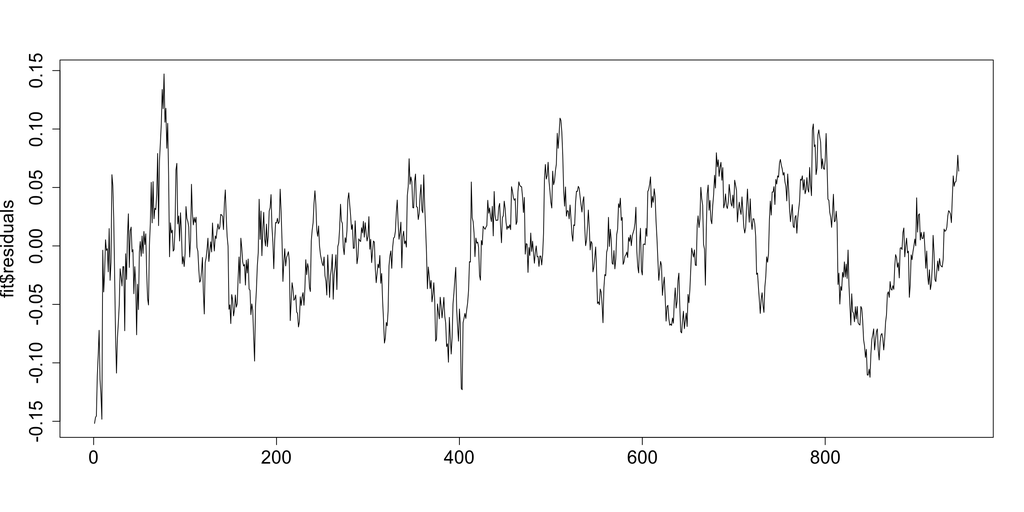

```r
plot(fit$residuals, type="l", cex.axis=1.5, cex.lab=1.5, xlab="")
```

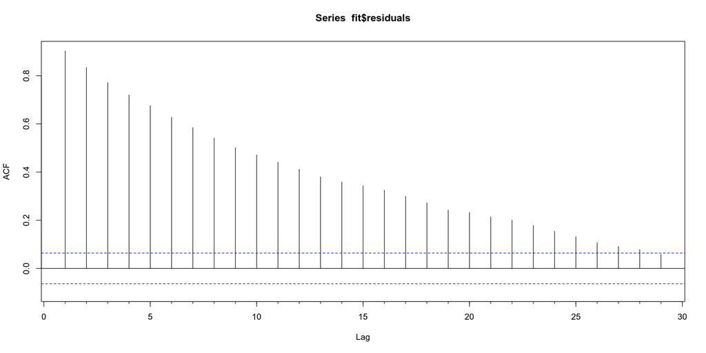

```r
Acf(fit$residuals)
```

```r
adf.test(fit$residuals, k=2)
```

```
##
##  Augmented Dickey-Fuller Test
##
## data:  fit$residuals
## Dickey-Fuller = -6.0306, Lag order = 2, p-value = 0.01
## alternative hypothesis: stationary
```

We are going to fit the VECM model and plot the implied spread, together with the 90% compatibility intervals:

[figure not shown]

```r
fit_ECM_pairs <- readRDS("models/Chapter_8/saved_RDS/fit_ECM_pairs.rds")
```

The horizontal lines indicate the +-standard deviation of the spread, which can be used as strategy to enter trades.